# Machine_Learning_Lab1

Huizi Yu

2/5/2020

For this section, we will illustrate the concept of cross validation / Bias and Variance Trade off by using the football dataset. You can find the data set folder here:

- football_train.csv: training set of the football dataset
- football_test.csv: testing set of the football dataset (without true response variable - Wins)
- football_answers.csv: true response variable for the testing set

For this post, we regard the answers to football_test as unavailabe during our model building/selection stage. We test our model’s performance by predicting the answers to football_test and comparing our prediction with the TRUE answers.

Content: (1) Simple EDA of the football dataset (2) Tricks for splitting dataset into training and testing (4) Bias Variance Trade Off (5) Introduce the package for cross validation

## Reading in the Data

```r
setwd("~/Dropbox/Projects/OSCR/ML_Lab1/Markdown")
train <- read.csv("~/Dropbox/Projects/OSCR/ML_Lab1/Datasets/football_train.csv")
test <- read.csv("~/Dropbox/Projects/OSCR/ML_Lab1/Datasets/football_test.csv")
true <- read.csv("~/Dropbox/Projects/OSCR/ML_Lab1/Datasets/football_answers.csv")
```

## Simple EDA

```r
library(sp)
library(corrplot)
library(ggcorrplot)
summary(train)
```

```
##        ID             Yards      OffensivePlays TurnOversLost    FumblesLost
##  Min.   :  1.00   Min.   :3572   Min.   : 865   Min.   :10.00   Min.   : 2.0
##  1st Qu.: 95.75   1st Qu.:4976   1st Qu.: 982   1st Qu.:21.00   1st Qu.: 8.0
##  Median :190.50   Median :5382   Median :1014   Median :25.00   Median :10.0
##  Mean   :190.50   Mean   :5383   Mean   :1013   Mean   :25.57   Mean   :10.5
##  3rd Qu.:285.25   3rd Qu.:5810   3rd Qu.:1045   3rd Qu.:30.00   3rd Qu.:13.0
##  Max.   :380.00   Max.   :7474   Max.   :1191   Max.   :45.00   Max.   :26.0
##    FirstDowns    PassesCompleted PassesAttempted YardsGainedPassing
##  Min.   :191.0   Min.   :204.0   Min.   :358.0   Min.   :1898
##  1st Qu.:282.0   1st Qu.:292.0   1st Qu.:491.0   1st Qu.:3091
##  Median :307.0   Median :326.0   Median :539.0   Median :3508
##  Mean   :307.9   Mean   :328.5   Mean   :537.5   Mean   :3543
##  3rd Qu.:331.0   3rd Qu.:364.2   3rd Qu.:584.2   3rd Qu.:3965
##  Max.   :444.0   Max.   :472.0   Max.   :740.0   Max.   :5444
##  InterceptionsThrown RushingAttempts YardsGainedRushing PenaltiesCommitedByTeam
##  Min.   : 2.00       Min.   :304.0   Min.   :1129       Min.   : 57.0
##  1st Qu.:12.00       1st Qu.:401.8   1st Qu.:1605       1st Qu.: 92.0
##  Median :15.00       Median :430.5   Median :1798       Median :102.0
##  Mean   :15.08       Mean   :439.2   Mean   :1839       Mean   :102.6
##  3rd Qu.:19.00       3rd Qu.:475.2   3rd Qu.:2040       3rd Qu.:113.0
##  Max.   :32.00       Max.   :618.0   Max.   :2939       Max.   :148.0
##  PenaltiesInYards FirstDownsByPenalty NumberOfDrives     OppYards
##  Min.   : 428.0   Min.   :12.00       Min.   :150.0   Min.   :4037
##  1st Qu.: 756.8   1st Qu.:22.00       1st Qu.:179.0   1st Qu.:4983
##  Median : 852.0   Median :26.00       Median :187.0   Median :5351
##  Mean   : 853.2   Mean   :27.15       Mean   :186.5   Mean   :5354
##  3rd Qu.: 952.2   3rd Qu.:32.00       3rd Qu.:193.0   3rd Qu.:5707
##  Max.   :1276.0   Max.   :50.00       Max.   :218.0   Max.   :6645
##  OppOffensivePlays OppTurnOversLost OppFumblesLost  OppFirstDowns
##  Min.   : 882      Min.   : 7.00    Min.   : 2.00   Min.   :228.0
##  1st Qu.: 979      1st Qu.:22.00    1st Qu.: 8.00   1st Qu.:285.8
##  Median :1009      Median :26.00    Median :11.00   Median :307.0
##  Mean   :1012      Mean   :26.28    Mean   :10.61   Mean   :305.7
##  3rd Qu.:1041      3rd Qu.:30.00    3rd Qu.:13.00   3rd Qu.:324.2
##  Max.   :1150      Max.   :48.00    Max.   :23.00   Max.   :419.0
##  OppPassesCompleted OppPassesAttempted OppYardsGainedPassing
##  Min.   :239.0      Min.   :430.0      Min.   :2459
##  1st Qu.:304.8      1st Qu.:511.0      1st Qu.:3250
##  Median :330.5      Median :538.5      Median :3536
##  Mean   :330.4      Mean   :541.1      Mean   :3549
```

[output cut: 8 more lines]

```
##  Max.   :31.00          Max.   :554.0      Max.   :2654
##  OppPenaltiesCommitedByTeam OppPenaltiesInYards OppFirstDownsByPenalty
##  Min.   : 64.0              Min.   : 498.0      Min.   : 7.00
##  1st Qu.: 93.0              1st Qu.: 764.8      1st Qu.:22.00
##  Median :103.0              Median : 862.0      Median :26.50
##  Mean   :102.9              Mean   : 859.8      Mean   :26.82
##  3rd Qu.:112.0              3rd Qu.: 945.8      3rd Qu.:32.00
##  Max.   :144.0              Max.   :1208.0      Max.   :54.00
##  OppNumberOfDrives      Wins
##  Min.   :153.0     Min.   : 0.000
##  1st Qu.:179.0     1st Qu.: 6.000
##  Median :186.0     Median : 8.000
##  Mean   :186.3     Mean   : 8.139
##  3rd Qu.:193.0     3rd Qu.:10.250
##  Max.   :218.0     Max.   :16.000
```

```r
sum(is.na(train)) ## there is no missing variable
```

```
## [1] 0
```

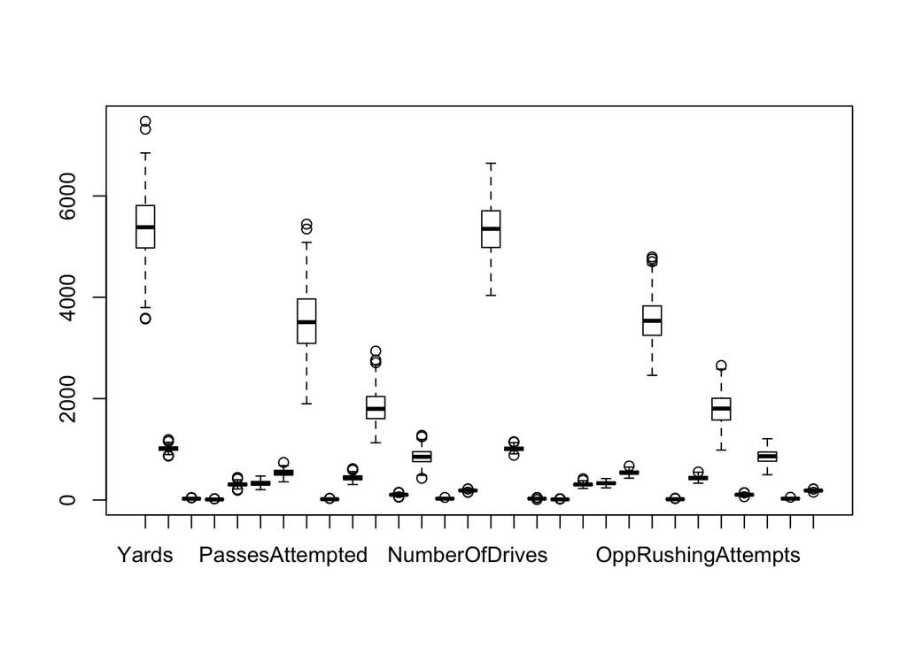

```r
boxplot(train[,-c(1,dim(train)[2])]) ## We remove the id variable and response variable to plot the distribution of each variable
```

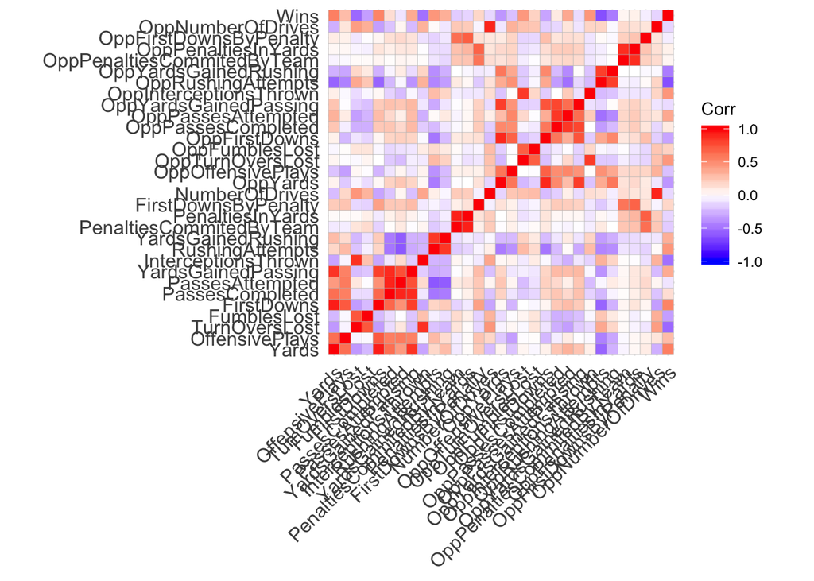

```r
cormat<-round(cor(train[,-1], use="pairwise.complete.obs"),2)
ggcorrplot(cormat,lab = FALSE) ## Wins appears to have strong correlation with Yards, Turnoverlost, OppsRushingAttempts
```

## Splitting data into training and testing

The purpose is to create an artificial testing dataset of which we know the outcome variable. We will not use this testing data when training our model, but because we know the outcome, we can evaluate our model accuracy with this dataset. A model with smaller MSE in testing dataset is likely to perform equally well on unknown real-life data set as well.

```r
set.seed(1234567)
samp_perc <-sample(1:nrow(train),nrow(train)*0.8,replace = F) ## we reserve 20% of data as holdoff set
training <-train[samp_perc,]
testing <- train[-samp_perc,]
```

## Bias Variance Trade Off

A Classification and Regression Tree is a flowchart-like structure in which each internal node represents a “test” on an attribute (e.g. whether a coin flip comes up heads or tails), each branch represents the outcome of the test, and each leaf node represents a class label (decision taken after computing all attributes). The paths from root to leaf represent classification rules and regression outcome. We will discussion the tree like structures in later posts

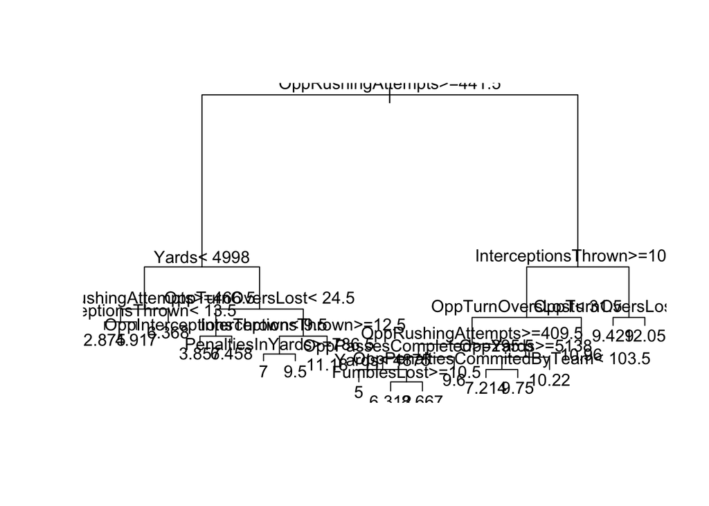

```r
## R already has built in function for evaluating variance, we create our custome function for calculating bias and MSE
get_bias = function(estimate, truth) {
  mean(estimate) - truth
}

get_mse = function(estimate, truth) {
  mean((estimate - truth) ^ 2)
}

## Start off with an overfitting algorithm
library(rpart)
mod1 <- rpart(Wins~.-ID, data = training)
plot(mod1) ## we can also visualize the decision tree
text(mod1, pretty = T) ## this gives up an extensive tree without pruning, this model likely overfits
```

```r
pred1 <- predict(mod1)
## Now let's try an underfitting algorithm, we try an extreme by predicting all response as the mean of the response
pred2 <- rep(mean(training$Wins), dim(training)[1])
## We choose a random observaation to test the variance and bias
set.seed(1234)
index <- sample(1:dim(training)[1],1)
get_bias(pred1[index],training$Wins[index])
```

```
## [1] -0.6315789
```

```r
get_bias(pred2[index],training$Wins[index])
```

```
## [1] 1.25
```

```r
var(pred1)
```

```
## [1] 7.411235
```

```r
var(pred2)
```

```
## [1] 0
```

```r
get_mse(pred1[index],training$Wins[index])
```

```
## [1] 0.398892
```

```r
get_mse(pred2[index],training$Wins[index])
```

```
## [1] 1.5625
```

From this simple example, we can observe that simple models are likely to have (1) small variance (0 in our extreme case) (2) large bias and our complex model is likely to have (1) small bias (2) high variance.

## Package for cross validation

```r
library(caret)
train.control_1 <- trainControl(method = "LOOCV") ## Leave one out cross validation
train.control_2 <- trainControl(method = "cv", number = 10) ## 10
mod3 <- train(Wins~.-ID, data = training, method = "rpart",
               trControl = train.control_2)
mod3
```

```
## CART
##
## 304 samples
##  31 predictor
##
## No pre-processing
## Resampling: Cross-Validated (10 fold)
## Summary of sample sizes: 273, 274, 274, 273, 274, 275, ...
## Resampling results across tuning parameters:
##
##   cp          RMSE      Rsquared   MAE
##   0.07268065  2.675776  0.3088341  2.095234
##   0.07683601  2.702184  0.2963450  2.103838
##   0.29699641  3.032189  0.1675492  2.456050
##
## RMSE was used to select the optimal model using the smallest value.
## The final value used for the model was cp = 0.07268065.
```